# Risk Factor Analysis

## Outcome Variable

**Outcome Variable:** whz

## Predictor Variables

**Intervention Variable:** birthlen

**Adjustment Set:**

- arm
- sex
- W_mage
- meducyrs
- feducyrs
- vagbrth
- single
- brthmon
- W_parity
- delta_W_mage
- delta_meducyrs
- delta_feducyrs
- delta_vagbrth
- delta_single
- delta_brthmon
- delta_W_parity

## Stratifying Variables

The analysis was stratified on these variable(s):

- agecat
- studyid
- country

## Data Summary

| agecat | studyid | country | birthlen | n_cell | n | outcome_variable |
| --- | --- | --- | --- | --- | --- | --- |
| Birth | CMC-V-BCS-2002 | INDIA | >=50 cm | 13 | 86 | whz |
| Birth | CMC-V-BCS-2002 | INDIA | <48 cm | 33 | 86 | whz |
| Birth | CMC-V-BCS-2002 | INDIA | [48-50) cm | 40 | 86 | whz |
| Birth | CMIN | BANGLADESH | >=50 cm | 2 | 19 | whz |
| Birth | CMIN | BANGLADESH | <48 cm | 12 | 19 | whz |
| Birth | CMIN | BANGLADESH | [48-50) cm | 5 | 19 | whz |
| Birth | COHORTS | GUATEMALA | >=50 cm | 396 | 756 | whz |
| Birth | COHORTS | GUATEMALA | <48 cm | 132 | 756 | whz |
| Birth | COHORTS | GUATEMALA | [48-50) cm | 228 | 756 | whz |
| Birth | COHORTS | INDIA | >=50 cm | 1404 | 6193 | whz |
| Birth | COHORTS | INDIA | <48 cm | 2354 | 6193 | whz |
| Birth | COHORTS | INDIA | [48-50) cm | 2435 | 6193 | whz |
| Birth | COHORTS | PHILIPPINES | >=50 cm | 1110 | 2899 | whz |
| Birth | COHORTS | PHILIPPINES | <48 cm | 651 | 2899 | whz |
| Birth | COHORTS | PHILIPPINES | [48-50) cm | 1138 | 2899 | whz |
| Birth | CONTENT | PERU | >=50 cm | 1 | 2 | whz |
| Birth | CONTENT | PERU | <48 cm | 1 | 2 | whz |
| Birth | CONTENT | PERU | [48-50) cm | 0 | 2 | whz |
| Birth | EE | PAKISTAN | >=50 cm | 19 | 177 | whz |
| Birth | EE | PAKISTAN | <48 cm | 112 | 177 | whz |
| Birth | EE | PAKISTAN | [48-50) cm | 46 | 177 | whz |
| Birth | GMS-Nepal | NEPAL | >=50 cm | 103 | 641 | whz |
| Birth | GMS-Nepal | NEPAL | <48 cm | 330 | 641 | whz |
| Birth | GMS-Nepal | NEPAL | [48-50) cm | 208 | 641 | whz |
| Birth | IRC | INDIA | >=50 cm | 120 | 343 | whz |
| Birth | IRC | INDIA | <48 cm | 87 | 343 | whz |
| Birth | IRC | INDIA | [48-50) cm | 136 | 343 | whz |
| Birth | JiVitA-3 | BANGLADESH | >=50 cm | 1213 | 18014 | whz |
| Birth | JiVitA-3 | BANGLADESH | <48 cm | 11719 | 18014 | whz |
| Birth | JiVitA-3 | BANGLADESH | [48-50) cm | 5082 | 18014 | whz |

[output cut: 198 more lines]

The following strata were considered:

- agecat: 24 months, studyid: CMC-V-BCS-2002, country: INDIA
- agecat: 24 months, studyid: CMIN, country: BANGLADESH
- agecat: 24 months, studyid: COHORTS, country: GUATEMALA
- agecat: 24 months, studyid: COHORTS, country: INDIA
- agecat: 24 months, studyid: COHORTS, country: PHILIPPINES
- agecat: 24 months, studyid: CONTENT, country: PERU
- agecat: 24 months, studyid: EE, country: PAKISTAN
- agecat: 24 months, studyid: GMS-Nepal, country: NEPAL
- agecat: 24 months, studyid: IRC, country: INDIA
- agecat: 24 months, studyid: JiVitA-3, country: BANGLADESH
- agecat: 24 months, studyid: JiVitA-4, country: BANGLADESH
- agecat: 24 months, studyid: Keneba, country: GAMBIA
- agecat: 24 months, studyid: MAL-ED, country: BANGLADESH
- agecat: 24 months, studyid: MAL-ED, country: BRAZIL
- agecat: 24 months, studyid: MAL-ED, country: INDIA
- agecat: 24 months, studyid: MAL-ED, country: NEPAL
- agecat: 24 months, studyid: MAL-ED, country: PERU
- agecat: 24 months, studyid: MAL-ED, country: SOUTH AFRICA
- agecat: 24 months, studyid: MAL-ED, country: TANZANIA, UNITED REPUBLIC OF
- agecat: 24 months, studyid: NIH-Birth, country: BANGLADESH
- agecat: 24 months, studyid: NIH-Crypto, country: BANGLADESH
- agecat: 24 months, studyid: PROBIT, country: BELARUS
- agecat: 24 months, studyid: PROVIDE, country: BANGLADESH
- agecat: 24 months, studyid: ZVITAMBO, country: ZIMBABWE
- agecat: 6 months, studyid: CMC-V-BCS-2002, country: INDIA
- agecat: 6 months, studyid: CMIN, country: BANGLADESH
- agecat: 6 months, studyid: COHORTS, country: GUATEMALA
- agecat: 6 months, studyid: COHORTS, country: INDIA
- agecat: 6 months, studyid: COHORTS, country: PHILIPPINES
- agecat: 6 months, studyid: CONTENT, country: PERU
- agecat: 6 months, studyid: EE, country: PAKISTAN
- agecat: 6 months, studyid: GMS-Nepal, country: NEPAL
- agecat: 6 months, studyid: IRC, country: INDIA
- agecat: 6 months, studyid: JiVitA-3, country: BANGLADESH
- agecat: 6 months, studyid: JiVitA-4, country: BANGLADESH
- agecat: 6 months, studyid: Keneba, country: GAMBIA
- agecat: 6 months, studyid: MAL-ED, country: BANGLADESH
- agecat: 6 months, studyid: MAL-ED, country: BRAZIL
- agecat: 6 months, studyid: MAL-ED, country: INDIA
- agecat: 6 months, studyid: MAL-ED, country: NEPAL
- agecat: 6 months, studyid: MAL-ED, country: PERU
- agecat: 6 months, studyid: MAL-ED, country: SOUTH AFRICA
- agecat: 6 months, studyid: MAL-ED, country: TANZANIA, UNITED REPUBLIC OF
- agecat: 6 months, studyid: NIH-Birth, country: BANGLADESH
- agecat: 6 months, studyid: NIH-Crypto, country: BANGLADESH
- agecat: 6 months, studyid: PROBIT, country: BELARUS
- agecat: 6 months, studyid: PROVIDE, country: BANGLADESH
- agecat: 6 months, studyid: ResPak, country: PAKISTAN
- agecat: 6 months, studyid: SAS-CompFeed, country: INDIA
- agecat: 6 months, studyid: ZVITAMBO, country: ZIMBABWE
- agecat: Birth, studyid: CMC-V-BCS-2002, country: INDIA
- agecat: Birth, studyid: CMIN, country: BANGLADESH
- agecat: Birth, studyid: COHORTS, country: GUATEMALA
- agecat: Birth, studyid: COHORTS, country: INDIA
- agecat: Birth, studyid: COHORTS, country: PHILIPPINES
- agecat: Birth, studyid: CONTENT, country: PERU
- agecat: Birth, studyid: EE, country: PAKISTAN
- agecat: Birth, studyid: GMS-Nepal, country: NEPAL
- agecat: Birth, studyid: IRC, country: INDIA
- agecat: Birth, studyid: JiVitA-3, country: BANGLADESH
- agecat: Birth, studyid: JiVitA-4, country: BANGLADESH
- agecat: Birth, studyid: Keneba, country: GAMBIA
- agecat: Birth, studyid: MAL-ED, country: BANGLADESH
- agecat: Birth, studyid: MAL-ED, country: BRAZIL
- agecat: Birth, studyid: MAL-ED, country: INDIA
- agecat: Birth, studyid: MAL-ED, country: NEPAL
- agecat: Birth, studyid: MAL-ED, country: PERU
- agecat: Birth, studyid: MAL-ED, country: SOUTH AFRICA
- agecat: Birth, studyid: MAL-ED, country: TANZANIA, UNITED REPUBLIC OF
- agecat: Birth, studyid: NIH-Birth, country: BANGLADESH
- agecat: Birth, studyid: NIH-Crypto, country: BANGLADESH
- agecat: Birth, studyid: PROBIT, country: BELARUS
- agecat: Birth, studyid: PROVIDE, country: BANGLADESH
- agecat: Birth, studyid: ResPak, country: PAKISTAN
- agecat: Birth, studyid: SAS-CompFeed, country: INDIA
- agecat: Birth, studyid: ZVITAMBO, country: ZIMBABWE

### Dropped Strata

Some strata were dropped due to rare outcomes:

- agecat: Birth, studyid: CMIN, country: BANGLADESH
- agecat: Birth, studyid: CONTENT, country: PERU
- agecat: 6 months, studyid: CMIN, country: BANGLADESH
- agecat: 6 months, studyid: CONTENT, country: PERU
- agecat: 24 months, studyid: CMIN, country: BANGLADESH
- agecat: 24 months, studyid: CONTENT, country: PERU

## Methods Detail

We’re interested in the causal parameters $E[Y_a]$ for all values of $a \in \mathcal{A}$. These parameters represent the mean outcome if, possibly contrary to fact, we intervened to set all units to have $A=a$. Under the randomization and positivity assumptions, these are identified by the statistical parameters $\psi_a=E_W[E_{Y|A,W}(Y|A=a,W)]$. In addition, we’re interested in the mean of $Y$, $E[Y]$ under no intervention (the observed mean). We will estimate these parameters by using SuperLearner to fit the relevant likelihood factors – $E_{Y|A,W}(Y|A=a,W)$ and $p(A=a|W)$, and then updating our likelihood fit using a joint TMLE.

For unadjusted analyses ($W=\{\}$), initial likelihoods were estimated using Lrnr_glm to estimate the simple $E(Y|A)$ and Lrnr_mean to estimate $p(A)$. For adjusted analyses, a small library containing Lrnr_glmnet, Lrnr_xgboost, and Lrnr_mean was used.

Having estimated these parameters, we will then use the delta method to estimate relative risks and attributable risks relative to a prespecified baseline level of $A$.

# Results Detail

## Results Plots

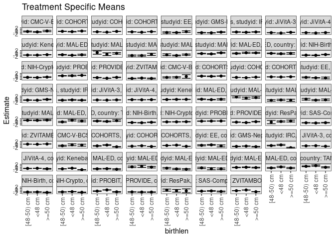

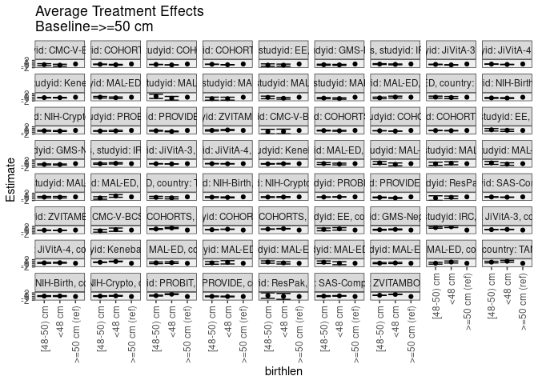

[figure not shown]

## Results Table

### Parameter: TSM

| agecat | studyid | country | intervention_level | baseline_level | estimate | ci_lower | ci_upper |
| --- | --- | --- | --- | --- | --- | --- | --- |
| Birth | CMC-V-BCS-2002 | INDIA | >=50 cm | NA | -0.3765533 | -1.0397087 | 0.2866022 |
| Birth | CMC-V-BCS-2002 | INDIA | <48 cm | NA | -0.1399679 | -0.7537966 | 0.4738608 |
| Birth | CMC-V-BCS-2002 | INDIA | [48-50) cm | NA | -0.7529085 | -1.1008000 | -0.4050169 |
| Birth | COHORTS | GUATEMALA | >=50 cm | NA | -1.4509040 | -1.5768762 | -1.3249318 |
| Birth | COHORTS | GUATEMALA | <48 cm | NA | -0.2997682 | -0.5667166 | -0.0328198 |
| Birth | COHORTS | GUATEMALA | [48-50) cm | NA | -0.8486706 | -1.0273938 | -0.6699474 |
| Birth | COHORTS | INDIA | >=50 cm | NA | -1.2412943 | -1.2998479 | -1.1827406 |
| Birth | COHORTS | INDIA | <48 cm | NA | -0.7630826 | -0.8134347 | -0.7127305 |
| Birth | COHORTS | INDIA | [48-50) cm | NA | -1.0444416 | -1.0908454 | -0.9980377 |
| Birth | COHORTS | PHILIPPINES | >=50 cm | NA | -1.1208623 | -1.1915117 | -1.0502129 |
| Birth | COHORTS | PHILIPPINES | <48 cm | NA | -0.3552738 | -0.4600340 | -0.2505137 |
| Birth | COHORTS | PHILIPPINES | [48-50) cm | NA | -0.5868241 | -0.6559232 | -0.5177250 |
| Birth | EE | PAKISTAN | >=50 cm | NA | -0.8589687 | -1.5049887 | -0.2129487 |
| Birth | EE | PAKISTAN | <48 cm | NA | -0.1864020 | -0.4144128 | 0.0416088 |
| Birth | EE | PAKISTAN | [48-50) cm | NA | -0.4819470 | -0.8623604 | -0.1015336 |
| Birth | GMS-Nepal | NEPAL | >=50 cm | NA | -1.3644920 | -1.5721282 | -1.1568558 |
| Birth | GMS-Nepal | NEPAL | <48 cm | NA | -0.9975057 | -1.1275372 | -0.8674742 |
| Birth | GMS-Nepal | NEPAL | [48-50) cm | NA | -1.1841049 | -1.3218203 | -1.0463896 |
| Birth | IRC | INDIA | >=50 cm | NA | -2.0506607 | -2.3406305 | -1.7606909 |
| Birth | IRC | INDIA | <48 cm | NA | -0.2066520 | -0.5692052 | 0.1559011 |
| Birth | IRC | INDIA | [48-50) cm | NA | -0.6465576 | -0.8991222 | -0.3939930 |
| Birth | JiVitA-3 | BANGLADESH | >=50 cm | NA | -1.0797673 | -1.1382207 | -1.0213140 |
| Birth | JiVitA-3 | BANGLADESH | <48 cm | NA | -0.7231790 | -0.7457503 | -0.7006077 |
| Birth | JiVitA-3 | BANGLADESH | [48-50) cm | NA | -0.8430936 | -0.8757355 | -0.8104517 |
| Birth | JiVitA-4 | BANGLADESH | >=50 cm | NA | -0.9750178 | -1.2144828 | -0.7355527 |
| Birth | JiVitA-4 | BANGLADESH | <48 cm | NA | -0.6412590 | -0.7066815 | -0.5758365 |
| Birth | JiVitA-4 | BANGLADESH | [48-50) cm | NA | -0.7325656 | -0.8305043 | -0.6346270 |
| Birth | Keneba | GAMBIA | >=50 cm | NA | -1.5921885 | -1.6745634 | -1.5098137 |
| Birth | Keneba | GAMBIA | <48 cm | NA | -0.5813227 | -0.7421361 | -0.4205093 |
| Birth | Keneba | GAMBIA | [48-50) cm | NA | -1.0096761 | -1.1089830 | -0.9103691 |

[output cut: 180 more lines]

### Parameter: E(Y)

| agecat | studyid | country | intervention_level | baseline_level | estimate | ci_lower | ci_upper |
| --- | --- | --- | --- | --- | --- | --- | --- |
| Birth | CMC-V-BCS-2002 | INDIA | NA | NA | -0.4648256 | -0.7643210 | -0.1653302 |
| Birth | COHORTS | GUATEMALA | NA | NA | -1.0621429 | -1.1631387 | -0.9611471 |
| Birth | COHORTS | INDIA | NA | NA | -0.9847457 | -1.0145305 | -0.9549609 |
| Birth | COHORTS | PHILIPPINES | NA | NA | -0.7427251 | -0.7890855 | -0.6963647 |
| Birth | EE | PAKISTAN | NA | NA | -0.3333051 | -0.5209779 | -0.1456323 |
| Birth | GMS-Nepal | NEPAL | NA | NA | -1.1164431 | -1.2040134 | -1.0288728 |
| Birth | IRC | INDIA | NA | NA | -1.0105831 | -1.1973019 | -0.8238643 |
| Birth | JiVitA-3 | BANGLADESH | NA | NA | -0.7778272 | -0.7968313 | -0.7588232 |
| Birth | JiVitA-4 | BANGLADESH | NA | NA | -0.6886269 | -0.7410452 | -0.6362086 |
| Birth | Keneba | GAMBIA | NA | NA | -1.2343618 | -1.2966897 | -1.1720339 |
| Birth | MAL-ED | BANGLADESH | NA | NA | -0.9418605 | -1.0869834 | -0.7967375 |
| Birth | MAL-ED | BRAZIL | NA | NA | 0.4029032 | 0.0896793 | 0.7161272 |
| Birth | MAL-ED | INDIA | NA | NA | -0.9324444 | -1.2067907 | -0.6580982 |
| Birth | MAL-ED | NEPAL | NA | NA | -0.7684615 | -1.1257770 | -0.4111460 |
| Birth | MAL-ED | PERU | NA | NA | -0.0520175 | -0.1725298 | 0.0684947 |
| Birth | MAL-ED | SOUTH AFRICA | NA | NA | -0.1925833 | -0.4053570 | 0.0201904 |
| Birth | MAL-ED | TANZANIA, UNITED REPUBLIC OF | NA | NA | 0.7624348 | 0.5710709 | 0.9537986 |
| Birth | NIH-Birth | BANGLADESH | NA | NA | -1.3499217 | -1.4444634 | -1.2553801 |
| Birth | NIH-Crypto | BANGLADESH | NA | NA | -1.2441513 | -1.3281130 | -1.1601897 |
| Birth | PROBIT | BELARUS | NA | NA | -1.1491782 | -1.3593933 | -0.9389630 |
| Birth | PROVIDE | BANGLADESH | NA | NA | -1.2984586 | -1.3752758 | -1.2216415 |
| Birth | ResPak | PAKISTAN | NA | NA | -0.3663158 | -0.7677415 | 0.0351099 |
| Birth | SAS-CompFeed | INDIA | NA | NA | -0.6700453 | -0.8474950 | -0.4925957 |
| Birth | ZVITAMBO | ZIMBABWE | NA | NA | -0.5154897 | -0.5413479 | -0.4896314 |
| 6 months | CMC-V-BCS-2002 | INDIA | NA | NA | -0.4931429 | -0.7890257 | -0.1972601 |
| 6 months | COHORTS | GUATEMALA | NA | NA | 0.2193904 | 0.1338361 | 0.3049448 |
| 6 months | COHORTS | INDIA | NA | NA | -0.6983940 | -0.7275858 | -0.6692022 |
| 6 months | COHORTS | PHILIPPINES | NA | NA | -0.2943461 | -0.3357404 | -0.2529517 |
| 6 months | EE | PAKISTAN | NA | NA | -0.8527871 | -0.9897809 | -0.7157933 |
| 6 months | GMS-Nepal | NEPAL | NA | NA | -0.6026850 | -0.6889114 | -0.5164586 |
| 6 months | IRC | INDIA | NA | NA | -0.6409340 | -0.7788045 | -0.5030635 |
| 6 months | JiVitA-3 | BANGLADESH | NA | NA | -0.6072473 | -0.6281750 | -0.5863195 |
| 6 months | JiVitA-4 | BANGLADESH | NA | NA | -0.3757033 | -0.4185197 | -0.3328869 |
| 6 months | Keneba | GAMBIA | NA | NA | -0.1974657 | -0.2592285 | -0.1357029 |
| 6 months | MAL-ED | BANGLADESH | NA | NA | -0.1458294 | -0.2842227 | -0.0074361 |
| 6 months | MAL-ED | BRAZIL | NA | NA | 0.8580508 | 0.5394364 | 1.1766653 |
| 6 months | MAL-ED | INDIA | NA | NA | -0.6644715 | -0.9812646 | -0.3476785 |
| 6 months | MAL-ED | NEPAL | NA | NA | -0.4072436 | -0.7125541 | -0.1019331 |
| 6 months | MAL-ED | PERU | NA | NA | 1.0510698 | 0.9102569 | 1.1918826 |
| 6 months | MAL-ED | SOUTH AFRICA | NA | NA | 0.4017921 | 0.1396820 | 0.6639023 |
| 6 months | MAL-ED | TANZANIA, UNITED REPUBLIC OF | NA | NA | 0.5110593 | 0.3321196 | 0.6899991 |
| 6 months | NIH-Birth | BANGLADESH | NA | NA | -0.4636760 | -0.5549942 | -0.3723578 |
| 6 months | NIH-Crypto | BANGLADESH | NA | NA | 0.0297622 | -0.0491685 | 0.1086930 |
| 6 months | PROBIT | BELARUS | NA | NA | 0.5741099 | 0.5141290 | 0.6340908 |
| 6 months | PROVIDE | BANGLADESH | NA | NA | -0.1990907 | -0.2817968 | -0.1163845 |
| 6 months | ResPak | PAKISTAN | NA | NA | 0.2176471 | -0.1948962 | 0.6301903 |
| 6 months | SAS-CompFeed | INDIA | NA | NA | -0.6674924 | -0.8047012 | -0.5302836 |
| 6 months | ZVITAMBO | ZIMBABWE | NA | NA | 0.3089671 | 0.2831612 | 0.3347730 |
| 24 months | CMC-V-BCS-2002 | INDIA | NA | NA | -0.4529088 | -0.6339053 | -0.2719123 |
| 24 months | COHORTS | GUATEMALA | NA | NA | -0.2016312 | -0.2740358 | -0.1292266 |
| 24 months | COHORTS | INDIA | NA | NA | -0.5945743 | -0.6244188 | -0.5647299 |
| 24 months | COHORTS | PHILIPPINES | NA | NA | -0.6103189 | -0.6471371 | -0.5735006 |
| 24 months | EE | PAKISTAN | NA | NA | -0.9929439 | -1.1707082 | -0.8151796 |
| 24 months | GMS-Nepal | NEPAL | NA | NA | -1.1336900 | -1.2226955 | -1.0446844 |
| 24 months | IRC | INDIA | NA | NA | -0.7536624 | -0.8467166 | -0.6606082 |
| 24 months | JiVitA-3 | BANGLADESH | NA | NA | -1.3046571 | -1.3299587 | -1.2793555 |
| 24 months | JiVitA-4 | BANGLADESH | NA | NA | -1.2411122 | -1.2752162 | -1.2070083 |
| 24 months | Keneba | GAMBIA | NA | NA | -0.7949018 | -0.8551887 | -0.7346150 |
| 24 months | MAL-ED | BANGLADESH | NA | NA | -0.8296257 | -0.9583167 | -0.7009347 |
| 24 months | MAL-ED | BRAZIL | NA | NA | 0.2347222 | -0.1702799 | 0.6397243 |
| 24 months | MAL-ED | INDIA | NA | NA | -1.1144872 | -1.3842438 | -0.8447305 |
| 24 months | MAL-ED | NEPAL | NA | NA | -0.8921154 | -1.1547051 | -0.6295257 |
| 24 months | MAL-ED | PERU | NA | NA | 0.0490417 | -0.0909855 | 0.1890689 |
| 24 months | MAL-ED | SOUTH AFRICA | NA | NA | 0.3919414 | 0.2031981 | 0.5806847 |
| 24 months | MAL-ED | TANZANIA, UNITED REPUBLIC OF | NA | NA | 0.1324519 | -0.0568428 | 0.3217466 |
| 24 months | NIH-Birth | BANGLADESH | NA | NA | -0.9069451 | -1.0069853 | -0.8069049 |
| 24 months | NIH-Crypto | BANGLADESH | NA | NA | -0.6103502 | -0.7050157 | -0.5156847 |
| 24 months | PROBIT | BELARUS | NA | NA | 0.6981406 | 0.5843775 | 0.8119038 |
| 24 months | PROVIDE | BANGLADESH | NA | NA | -0.8928670 | -0.9755153 | -0.8102187 |
| 24 months | ZVITAMBO | ZIMBABWE | NA | NA | -1.1803052 | -1.2806626 | -1.0799477 |

### Parameter: ATE

| agecat | studyid | country | intervention_level | baseline_level | estimate | ci_lower | ci_upper |
| --- | --- | --- | --- | --- | --- | --- | --- |
| Birth | CMC-V-BCS-2002 | INDIA | >=50 cm | >=50 cm | 0.0000000 | 0.0000000 | 0.0000000 |
| Birth | CMC-V-BCS-2002 | INDIA | <48 cm | >=50 cm | 0.2365853 | -0.6711656 | 1.1443362 |
| Birth | CMC-V-BCS-2002 | INDIA | [48-50) cm | >=50 cm | -0.3763552 | -1.1299409 | 0.3772305 |
| Birth | COHORTS | GUATEMALA | >=50 cm | >=50 cm | 0.0000000 | 0.0000000 | 0.0000000 |
| Birth | COHORTS | GUATEMALA | <48 cm | >=50 cm | 1.1511358 | 0.8560638 | 1.4462077 |
| Birth | COHORTS | GUATEMALA | [48-50) cm | >=50 cm | 0.6022334 | 0.3839179 | 0.8205489 |
| Birth | COHORTS | INDIA | >=50 cm | >=50 cm | 0.0000000 | 0.0000000 | 0.0000000 |
| Birth | COHORTS | INDIA | <48 cm | >=50 cm | 0.4782117 | 0.4011385 | 0.5552848 |
| Birth | COHORTS | INDIA | [48-50) cm | >=50 cm | 0.1968527 | 0.1222799 | 0.2714255 |
| Birth | COHORTS | PHILIPPINES | >=50 cm | >=50 cm | 0.0000000 | 0.0000000 | 0.0000000 |
| Birth | COHORTS | PHILIPPINES | <48 cm | >=50 cm | 0.7655885 | 0.6397674 | 0.8914095 |
| Birth | COHORTS | PHILIPPINES | [48-50) cm | >=50 cm | 0.5340382 | 0.4357687 | 0.6323077 |
| Birth | EE | PAKISTAN | >=50 cm | >=50 cm | 0.0000000 | 0.0000000 | 0.0000000 |
| Birth | EE | PAKISTAN | <48 cm | >=50 cm | 0.6725667 | -0.0136313 | 1.3587647 |
| Birth | EE | PAKISTAN | [48-50) cm | >=50 cm | 0.3770217 | -0.3738662 | 1.1279096 |
| Birth | GMS-Nepal | NEPAL | >=50 cm | >=50 cm | 0.0000000 | 0.0000000 | 0.0000000 |
| Birth | GMS-Nepal | NEPAL | <48 cm | >=50 cm | 0.3669863 | 0.1223213 | 0.6116513 |
| Birth | GMS-Nepal | NEPAL | [48-50) cm | >=50 cm | 0.1803871 | -0.0679395 | 0.4287137 |
| Birth | IRC | INDIA | >=50 cm | >=50 cm | 0.0000000 | 0.0000000 | 0.0000000 |
| Birth | IRC | INDIA | <48 cm | >=50 cm | 1.8440087 | 1.3797767 | 2.3082406 |
| Birth | IRC | INDIA | [48-50) cm | >=50 cm | 1.4041031 | 1.0178591 | 1.7903470 |
| Birth | JiVitA-3 | BANGLADESH | >=50 cm | >=50 cm | 0.0000000 | 0.0000000 | 0.0000000 |
| Birth | JiVitA-3 | BANGLADESH | <48 cm | >=50 cm | 0.3565883 | 0.2956983 | 0.4174784 |
| Birth | JiVitA-3 | BANGLADESH | [48-50) cm | >=50 cm | 0.2366737 | 0.1719405 | 0.3014070 |
| Birth | JiVitA-4 | BANGLADESH | >=50 cm | >=50 cm | 0.0000000 | 0.0000000 | 0.0000000 |
| Birth | JiVitA-4 | BANGLADESH | <48 cm | >=50 cm | 0.3337588 | 0.0853497 | 0.5821678 |
| Birth | JiVitA-4 | BANGLADESH | [48-50) cm | >=50 cm | 0.2424521 | -0.0164627 | 0.5013670 |
| Birth | Keneba | GAMBIA | >=50 cm | >=50 cm | 0.0000000 | 0.0000000 | 0.0000000 |
| Birth | Keneba | GAMBIA | <48 cm | >=50 cm | 1.0108658 | 0.8303711 | 1.1913605 |
| Birth | Keneba | GAMBIA | [48-50) cm | >=50 cm | 0.5825125 | 0.4538683 | 0.7111566 |

[output cut: 180 more lines]

### Parameter: PAR

| agecat | studyid | country | intervention_level | baseline_level | estimate | ci_lower | ci_upper |
| --- | --- | --- | --- | --- | --- | --- | --- |
| Birth | CMC-V-BCS-2002 | INDIA | >=50 cm | NA | -0.0882723 | -0.7409440 | 0.5643994 |
| Birth | COHORTS | GUATEMALA | >=50 cm | NA | 0.3887611 | 0.2916305 | 0.4858918 |
| Birth | COHORTS | INDIA | >=50 cm | NA | 0.2565486 | 0.2037138 | 0.3093833 |
| Birth | COHORTS | PHILIPPINES | >=50 cm | NA | 0.3781372 | 0.3208174 | 0.4354570 |
| Birth | EE | PAKISTAN | >=50 cm | NA | 0.5256636 | -0.0815754 | 1.1329026 |
| Birth | GMS-Nepal | NEPAL | >=50 cm | NA | 0.2480490 | 0.0560615 | 0.4400364 |
| Birth | IRC | INDIA | >=50 cm | NA | 1.0400776 | 0.7919584 | 1.2881969 |
| Birth | JiVitA-3 | BANGLADESH | >=50 cm | NA | 0.3019401 | 0.2465058 | 0.3573744 |
| Birth | JiVitA-4 | BANGLADESH | >=50 cm | NA | 0.2863909 | 0.0585079 | 0.5142739 |
| Birth | Keneba | GAMBIA | >=50 cm | NA | 0.3578267 | 0.2961389 | 0.4195146 |
| Birth | MAL-ED | BANGLADESH | >=50 cm | NA | 0.3286728 | -0.0215219 | 0.6788674 |
| Birth | MAL-ED | BRAZIL | >=50 cm | NA | 0.3011711 | -0.1284191 | 0.7307613 |
| Birth | MAL-ED | INDIA | >=50 cm | NA | 0.3431111 | -0.0993435 | 0.7855657 |
| Birth | MAL-ED | NEPAL | >=50 cm | NA | 0.2001099 | -0.2975966 | 0.6978164 |
| Birth | MAL-ED | PERU | >=50 cm | NA | 0.1196972 | -0.1259614 | 0.3653558 |
| Birth | MAL-ED | SOUTH AFRICA | >=50 cm | NA | 0.2464744 | -0.0872047 | 0.5801534 |
| Birth | MAL-ED | TANZANIA, UNITED REPUBLIC OF | >=50 cm | NA | 0.7551624 | 0.3855970 | 1.1247279 |
| Birth | NIH-Birth | BANGLADESH | >=50 cm | NA | 0.2096368 | 0.0398258 | 0.3794478 |
| Birth | NIH-Crypto | BANGLADESH | >=50 cm | NA | 0.2298632 | 0.0836215 | 0.3761049 |
| Birth | PROBIT | BELARUS | >=50 cm | NA | 0.0532224 | 0.0287411 | 0.0777036 |
| Birth | PROVIDE | BANGLADESH | >=50 cm | NA | 0.0411035 | -0.1006449 | 0.1828520 |
| Birth | ResPak | PAKISTAN | >=50 cm | NA | 0.1717124 | -1.0247697 | 1.3681944 |
| Birth | SAS-CompFeed | INDIA | >=50 cm | NA | 0.2744625 | 0.1120072 | 0.4369178 |
| Birth | ZVITAMBO | ZIMBABWE | >=50 cm | NA | 0.6140262 | 0.5764748 | 0.6515776 |
| 6 months | CMC-V-BCS-2002 | INDIA | >=50 cm | NA | -0.4589028 | -1.5174783 | 0.5996727 |
| 6 months | COHORTS | GUATEMALA | >=50 cm | NA | -0.0536188 | -0.1386075 | 0.0313699 |
| 6 months | COHORTS | INDIA | >=50 cm | NA | -0.2183095 | -0.2718226 | -0.1647964 |
| 6 months | COHORTS | PHILIPPINES | >=50 cm | NA | -0.0503350 | -0.1043592 | 0.0036892 |
| 6 months | EE | PAKISTAN | >=50 cm | NA | 0.1416539 | -0.4156374 | 0.6989451 |
| 6 months | GMS-Nepal | NEPAL | >=50 cm | NA | -0.3815554 | -0.5866228 | -0.1764880 |
| 6 months | IRC | INDIA | >=50 cm | NA | 0.0295705 | -0.1549168 | 0.2140578 |
| 6 months | JiVitA-3 | BANGLADESH | >=50 cm | NA | -0.1174844 | -0.1963029 | -0.0386659 |
| 6 months | JiVitA-4 | BANGLADESH | >=50 cm | NA | -0.0323340 | -0.1000635 | 0.0353955 |
| 6 months | Keneba | GAMBIA | >=50 cm | NA | -0.0423997 | -0.1043490 | 0.0195495 |
| 6 months | MAL-ED | BANGLADESH | >=50 cm | NA | -0.0495136 | -0.4359241 | 0.3368970 |
| 6 months | MAL-ED | BRAZIL | >=50 cm | NA | -0.1933683 | -0.6131088 | 0.2263722 |
| 6 months | MAL-ED | INDIA | >=50 cm | NA | 0.0857368 | -0.5470478 | 0.7185213 |
| 6 months | MAL-ED | NEPAL | >=50 cm | NA | 0.0348993 | -0.4608742 | 0.5306727 |
| 6 months | MAL-ED | PERU | >=50 cm | NA | -0.1409876 | -0.4484527 | 0.1664774 |
| 6 months | MAL-ED | SOUTH AFRICA | >=50 cm | NA | -0.1901871 | -0.6582693 | 0.2778952 |
| 6 months | MAL-ED | TANZANIA, UNITED REPUBLIC OF | >=50 cm | NA | -0.3371893 | -0.8002580 | 0.1258794 |
| 6 months | NIH-Birth | BANGLADESH | >=50 cm | NA | -0.1986448 | -0.3857956 | -0.0114939 |
| 6 months | NIH-Crypto | BANGLADESH | >=50 cm | NA | -0.0814342 | -0.2248924 | 0.0620239 |
| 6 months | PROBIT | BELARUS | >=50 cm | NA | -0.0090331 | -0.0180910 | 0.0000247 |
| 6 months | PROVIDE | BANGLADESH | >=50 cm | NA | -0.3403053 | -0.4952884 | -0.1853222 |
| 6 months | ResPak | PAKISTAN | >=50 cm | NA | -0.3179779 | -0.9231607 | 0.2872048 |
| 6 months | SAS-CompFeed | INDIA | >=50 cm | NA | -0.1278319 | -0.2235222 | -0.0321417 |
| 6 months | ZVITAMBO | ZIMBABWE | >=50 cm | NA | -0.0858835 | -0.1264316 | -0.0453354 |
| 24 months | CMC-V-BCS-2002 | INDIA | >=50 cm | NA | -0.4530810 | -0.8836397 | -0.0225223 |
| 24 months | COHORTS | GUATEMALA | >=50 cm | NA | -0.1438257 | -0.2213833 | -0.0662682 |
| 24 months | COHORTS | INDIA | >=50 cm | NA | -0.3010933 | -0.3561523 | -0.2460343 |
| 24 months | COHORTS | PHILIPPINES | >=50 cm | NA | -0.1620341 | -0.2093473 | -0.1147210 |
| 24 months | EE | PAKISTAN | >=50 cm | NA | -0.5569118 | -1.0813637 | -0.0324599 |
| 24 months | GMS-Nepal | NEPAL | >=50 cm | NA | -0.3617430 | -0.5826788 | -0.1408073 |
| 24 months | IRC | INDIA | >=50 cm | NA | -0.0834253 | -0.2096560 | 0.0428053 |
| 24 months | JiVitA-3 | BANGLADESH | >=50 cm | NA | -0.3950623 | -0.5098972 | -0.2802274 |
| 24 months | JiVitA-4 | BANGLADESH | >=50 cm | NA | -0.1307380 | -0.1891999 | -0.0722762 |
| 24 months | Keneba | GAMBIA | >=50 cm | NA | -0.1221350 | -0.1826854 | -0.0615846 |
| 24 months | MAL-ED | BANGLADESH | >=50 cm | NA | -0.0984331 | -0.4320950 | 0.2352287 |
| 24 months | MAL-ED | BRAZIL | >=50 cm | NA | 0.0091922 | -0.4757757 | 0.4941601 |
| 24 months | MAL-ED | INDIA | >=50 cm | NA | -0.6786538 | -1.3465606 | -0.0107471 |
| 24 months | MAL-ED | NEPAL | >=50 cm | NA | -0.2742582 | -0.6557761 | 0.1072596 |
| 24 months | MAL-ED | PERU | >=50 cm | NA | -0.5281613 | -0.8092187 | -0.2471039 |
| 24 months | MAL-ED | SOUTH AFRICA | >=50 cm | NA | -0.1562338 | -0.4503254 | 0.1378577 |
| 24 months | MAL-ED | TANZANIA, UNITED REPUBLIC OF | >=50 cm | NA | -0.0474736 | -0.5014126 | 0.4064655 |
| 24 months | NIH-Birth | BANGLADESH | >=50 cm | NA | -0.3329848 | -0.5030574 | -0.1629122 |
| 24 months | NIH-Crypto | BANGLADESH | >=50 cm | NA | -0.1738788 | -0.3393236 | -0.0084339 |
| 24 months | PROBIT | BELARUS | >=50 cm | NA | -0.0237109 | -0.0429814 | -0.0044405 |
| 24 months | PROVIDE | BANGLADESH | >=50 cm | NA | -0.2573897 | -0.4123209 | -0.1024585 |
| 24 months | ZVITAMBO | ZIMBABWE | >=50 cm | NA | 0.1516421 | -0.1330035 | 0.4362878 |